# Class_kmeans slides

## Clustering Kmeans

[figure not shown]

The Iris flower data set or Fisher's Iris data set is a multivariate data set introduced by the British statistician, eugenicist, and biologist Ronald Fisher in his 1936 paper The use of multiple measurements in taxonomic problems as an example of linear discriminant analysis.[1] It is sometimes called Anderson's Iris data set because Edgar Anderson collected the data to quantify the morphologic variation of Iris flowers of three related species.[2] Two of the three species were collected in the Gaspé Peninsula "all from the same pasture, and picked on the same day and measured at the same time by the same person with the same apparatus".[3] Fisher's paper was published in the journal, the Annals of Eugenics, creating controversy about the continued use of the Iris dataset for teaching statistical techniques today.

The data set consists of 50 samples from each of three species of Iris (Iris setosa, Iris virginica and Iris versicolor). Four features were measured from each sample: the length and the width of the sepals and petals, in centimeters. Based on the combination of these four features, Fisher developed a linear discriminant model to distinguish the species from each other.

The data set contains 3 classes with 50 instances each, and 150 instances in total, where each class refers to a type of iris plant.

Class : Iris Setosa,Iris Versicolour, Iris Virginica

The format for the data: (sepal length, sepal width, petal length, petal width)

We will be training our models based on these parameters and further use them to predict the flower classes.

## Unsupervised Learning:

Unsupervised learning is used against data without any historical labels. The system is not subjected to a pre-determined set of outputs, correlations between inputs and outputs or a “correct answer.” The algorithm must figure out what it is viewing by itself, as it does not have any storage of reference points. The goal is to explore the data and find some sort of patterns or structures.

Unsupervised learning can be classified into:

● Clustering: Clustering is the task of dividing the population or data points into several groups, such that data points in a group are homogenous to each other than those in different groups. There are numerous clustering algorithms, some of them are – “K-means clustering algorithms”, “mean shift”, “hierarchal clustering”, etc.

This study we try to clustering Iris Dataset used Kmeans

Attribute Information:

- sepal length in cm
- sepal width in cm
- petal length in cm
- petal width in cm
- class: -- Iris Setosa -- Iris Versicolour -- Iris Virginica

K-means Clustering: The goal of the K-means clustering algorithm is to find groups in the data, with the number of groups represented by the variable K. The algorithm works iteratively to assign each data point to one of the K groups based on the features that are provided.

How to Implementing K-Means Clustering ?

- Choose the number of clusters k
- Select k random points from the data as centroids
- Assign all the points to the closest cluster centroid
- Recompute the centroids of newly formed clusters
- Repeat steps 3 and 4

## [Kmeans](https://www.youtube.com/watch?v=4b5d3muPQmA)

[figure not shown]

import libraries and load the data

```python
from sklearn import datasets #sklearn
import matplotlib.pyplot as plt # for visualization
import pandas as pd # table
from sklearn.cluster import KMeans # function

import warnings
warnings.filterwarnings("ignore")

iris = datasets.load_iris()# load data

### explore data
# feature names
print("Feature name：" + str(iris.feature_names))

# instances
print("First instance：" + str(iris.data[:1]))

# outcomes or labels
print("outcome or class label：" + str(iris.target[:1]))
```

[output not shown]

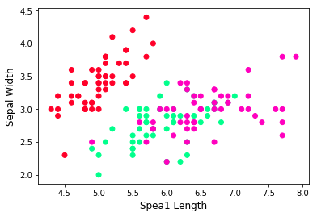

```python
X = iris.data[:, :2]
y = iris.target

# 3d plot
plt.scatter(X[:,0], X[:,1], c=y, cmap='gist_rainbow')
plt.xlabel('Spea1 Length', fontsize=12)
plt.ylabel('Sepal Width', fontsize=12)
```

Can we find clear pattern for classify the 3 species

```python
### Build the kmean model
km = KMeans(n_clusters = 3)
km.fit(X) #trainging

# find the center point
centers = km.cluster_centers_
print(centers)
```

```
[[6.81276596 3.07446809]
 [5.006      3.428     ]
 [5.77358491 2.69245283]]
```

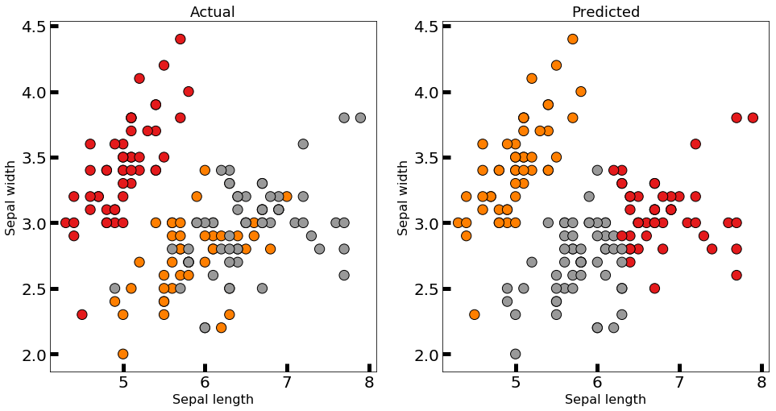

```python
# actual point and kmean result
predicted_labels = km.labels_

fig, axes = plt.subplots(1, 2, figsize=(16,8))
axes[0].scatter(X[:, 0], X[:, 1], c=y, cmap=plt.cm.Set1,
                edgecolor='k', s=150)
axes[1].scatter(X[:, 0], X[:, 1], c=predicted_labels, cmap=plt.cm.Set1,
                edgecolor='k', s=150)
axes[0].set_xlabel('Sepal length', fontsize=16)
axes[0].set_ylabel('Sepal width', fontsize=16)
axes[1].set_xlabel('Sepal length', fontsize=16)
axes[1].set_ylabel('Sepal width', fontsize=16)
axes[0].tick_params(direction='in', length=10, width=5, colors='k', labelsize=20)
axes[1].tick_params(direction='in', length=10, width=5, colors='k', labelsize=20)
axes[0].set_title('Actual', fontsize=18)
axes[1].set_title('Predicted', fontsize=18)
```

## Not always good, why?

# user cluster assignment

```python
import warnings
warnings.filterwarnings("ignore")
```

## 1. load data

```python
import pandas as pd
data = pd.read_csv('Mall_Customers.csv')
data.head()
```

|  | CustomerID | Gender | Age | Annual_Income (k$) | Spending_Score | visits_p12 | morning_visits_p12 | afternoon_visit_p12 | evening_visits_p12 | morning_spending_score | ... | weekend_visits_p12 | weekday_spending_score | weekend_spending_score | fiirst_visit_till_today | with_kids_visits_p12 | with_couple_visits_p12 | clothing_spending_score | food&beverage_spending_score | entertainment_spending_score | kids_spending_score |
| --- | --- | --- | --- | --- | --- | --- | --- | --- | --- | --- | --- | --- | --- | --- | --- | --- | --- | --- | --- | --- | --- |
| 0 | 4 | Female | 23 | 16 | 77 | 44 | 44 | 0 | 0 | 77 | ... | 0 | 77 | 0 | 269.0 | 0 | 0 | 0 | 77 | 0 | 0 |
| 1 | 2 | Male | 21 | 15 | 81 | 120 | 0 | 120 | 0 | 0 | ... | 0 | 81 | 0 | 210.0 | 0 | 0 | 0 | 81 | 0 | 0 |
| 2 | 3 | Female | 20 | 16 | 6 | 2 | 0 | 0 | 2 | 0 | ... | 2 | 0 | 6 | 157.0 | 0 | 2 | 0 | 3 | 3 | 0 |
| 3 | 1 | Male | 19 | 15 | 39 | 10 | 0 | 0 | 10 | 0 | ... | 0 | 39 | 0 | 634.0 | 0 | 8 | 0 | 30 | 9 | 0 |
| 4 | 61 | Male | 70 | 46 | 56 | 31 | 0 | 0 | 31 | 0 | ... | 13 | 40 | 16 | 700.0 | 0 | 31 | 6 | 50 | 0 | 0 |

5 rows × 23 columns

## 2. change the Gender to femal 1，male 0

```python
import numpy as np
data.Gender[data['Gender'] == 'Female']=1
data.Gender[data['Gender'] == 'Male']=0
data.head()
```

|  | CustomerID | Gender | Age | Annual_Income (k$) | Spending_Score | visits_p12 | morning_visits_p12 | afternoon_visit_p12 | evening_visits_p12 | morning_spending_score | ... | weekend_visits_p12 | weekday_spending_score | weekend_spending_score | fiirst_visit_till_today | with_kids_visits_p12 | with_couple_visits_p12 | clothing_spending_score | food&beverage_spending_score | entertainment_spending_score | kids_spending_score |
| --- | --- | --- | --- | --- | --- | --- | --- | --- | --- | --- | --- | --- | --- | --- | --- | --- | --- | --- | --- | --- | --- |
| 0 | 4 | 1 | 23 | 16 | 77 | 44 | 44 | 0 | 0 | 77 | ... | 0 | 77 | 0 | 269.0 | 0 | 0 | 0 | 77 | 0 | 0 |
| 1 | 2 | 0 | 21 | 15 | 81 | 120 | 0 | 120 | 0 | 0 | ... | 0 | 81 | 0 | 210.0 | 0 | 0 | 0 | 81 | 0 | 0 |
| 2 | 3 | 1 | 20 | 16 | 6 | 2 | 0 | 0 | 2 | 0 | ... | 2 | 0 | 6 | 157.0 | 0 | 2 | 0 | 3 | 3 | 0 |
| 3 | 1 | 0 | 19 | 15 | 39 | 10 | 0 | 0 | 10 | 0 | ... | 0 | 39 | 0 | 634.0 | 0 | 8 | 0 | 30 | 9 | 0 |
| 4 | 61 | 0 | 70 | 46 | 56 | 31 | 0 | 0 | 31 | 0 | ... | 13 | 40 | 16 | 700.0 | 0 | 31 | 6 | 50 | 0 | 0 |

5 rows × 23 columns

## 3. Build the kmean model

```python
import warnings
warnings.filterwarnings("ignore")
from sklearn.cluster import KMeans
```

```python
KMeans(n_clusters=2,max_iter=300)
```

```
KMeans(algorithm='auto', copy_x=True, init='k-means++', max_iter=300,
    n_clusters=2, n_init=10, n_jobs=None, precompute_distances='auto',
    random_state=None, tol=0.0001, verbose=0)
```

## 4. find the center in multi-dim from gender, age, incomes and spending

```python
CustomerGroupKmeans = KMeans(n_clusters=2,max_iter=300).fit(data[['Gender','Age','Annual_Income (k$)','Spending_Score']])
pd.DataFrame(CustomerGroupKmeans.cluster_centers_,columns=['Gender','Age','Annual_Income (k$)','Spending_Score'])
```

|  | Gender | Age | Annual_Income (k$) | Spending_Score |
| --- | --- | --- | --- | --- |
| 0 | 0.552941 | 28.952941 | 62.176471 | 73.623529 |
| 1 | 0.565217 | 46.165217 | 59.365217 | 32.886957 |

```python
import matplotlib.pyplot as plt

plt.figure()
plt.scatter(data['Annual_Income (k$)'], data['Spending_Score'],c=CustomerGroupKmeans.labels_)
plt.title("K-means test")
plt.show()
```

[output not shown]

```python
CustomerGroupKmeans = KMeans(n_clusters=4,max_iter=300).fit(data[['Gender','Age','Annual_Income (k$)','Spending_Score']])
pd.DataFrame(CustomerGroupKmeans.cluster_centers_,columns=['Gender','Age','Annual_Income (k$)','Spending_Score'])
```

|  | Gender | Age | Annual_Income (k$) | Spending_Score |
| --- | --- | --- | --- | --- |
| 0 | 0.500000 | 24.821429 | 28.714286 | 74.250000 |
| 1 | 0.621053 | 44.894737 | 48.705263 | 42.631579 |
| 2 | 0.538462 | 32.692308 | 86.538462 | 82.128205 |
| 3 | 0.473684 | 40.394737 | 87.000000 | 18.631579 |

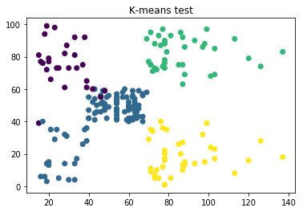

```python
import matplotlib.pyplot as plt

plt.figure()
plt.scatter(data['Annual_Income (k$)'], data['Spending_Score'],c=CustomerGroupKmeans.labels_)
plt.title("K-means test")
plt.show()
```

```python
CustomerGroupKmeans = KMeans(n_clusters=5,max_iter=300).fit(data[['Gender','Age','Annual_Income (k$)','Spending_Score']])
pd.DataFrame(CustomerGroupKmeans.cluster_centers_,columns=['Gender','Age','Annual_Income (k$)','Spending_Score'])
```

|  | Gender | Age | Annual_Income (k$) | Spending_Score |
| --- | --- | --- | --- | --- |
| 0 | 0.608696 | 25.521739 | 26.304348 | 78.565217 |
| 1 | 0.582278 | 43.088608 | 55.291139 | 49.569620 |
| 2 | 0.472222 | 40.666667 | 87.750000 | 17.583333 |
| 3 | 0.538462 | 32.692308 | 86.538462 | 82.128205 |
| 4 | 0.608696 | 45.217391 | 26.304348 | 20.913043 |

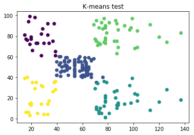

```python
import matplotlib.pyplot as plt

plt.figure()
plt.scatter(data['Annual_Income (k$)'], data['Spending_Score'],c=CustomerGroupKmeans.labels_)
plt.title("K-means test")
plt.show()
```

## 5. We can put normal days vs weekend

```python
CustomerGroupKmeans = KMeans(n_clusters=10,max_iter=300).fit(data[['Gender','Age','Annual_Income (k$)','Spending_Score','weekday_visits_p12','weekend_visits_p12','visits_p12','weekday_spending_score','weekend_spending_score']])
pd.DataFrame(CustomerGroupKmeans.cluster_centers_,columns=['Gender','Age','Annual_Income (k$)','Spending_Score','weekday_visits_p12','weekend_visits_p12','visits_p12','weekday_spending_score','weekend_spending_score'])
```

|  | Gender | Age | Annual_Income (k$) | Spending_Score | weekday_visits_p12 | weekend_visits_p12 | visits_p12 | weekday_spending_score | weekend_spending_score |
| --- | --- | --- | --- | --- | --- | --- | --- | --- | --- |
| 0 | 0.526316 | 40.684211 | 86.684211 | 16.210526 | 10.052632 | 8.052632 | 18.105263 | 6.000000 | 10.210526 |
| 1 | 0.605263 | 38.184211 | 59.289474 | 47.473684 | 22.342105 | 24.157895 | 46.500000 | 10.789474 | 36.684211 |
| 2 | 0.615385 | 31.692308 | 80.000000 | 82.076923 | 34.923077 | 7.692308 | 42.615385 | 49.384615 | 32.692308 |
| 3 | 0.500000 | 57.000000 | 76.000000 | 48.800000 | 28.100000 | 73.500000 | 101.600000 | 14.200000 | 34.600000 |
| 4 | 0.272727 | 42.545455 | 87.000000 | 14.090909 | 21.545455 | 44.454545 | 66.000000 | 2.090909 | 12.000000 |
| 5 | 0.657143 | 40.257143 | 51.857143 | 50.600000 | 10.085714 | 5.628571 | 15.714286 | 16.742857 | 33.857143 |
| 6 | 0.619048 | 44.142857 | 25.142857 | 19.523810 | 7.380952 | 7.523810 | 14.904762 | 5.904762 | 13.619048 |
| 7 | 0.250000 | 54.250000 | 64.250000 | 50.750000 | 82.875000 | 16.500000 | 99.375000 | 40.875000 | 9.875000 |
| 8 | 0.500000 | 27.192308 | 37.269231 | 80.346154 | 4.346154 | 6.038462 | 10.384615 | 17.115385 | 63.230769 |
| 9 | 0.631579 | 32.578947 | 85.736842 | 81.157895 | 20.000000 | 31.894737 | 51.894737 | 9.631579 | 71.526316 |

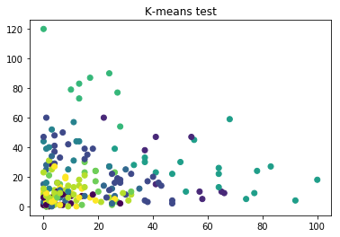

```python
import matplotlib.pyplot as plt

plt.figure()
plt.scatter(data['weekend_visits_p12'], data['weekday_visits_p12'],c=CustomerGroupKmeans.labels_)
plt.title("K-means test")
plt.show()
```

## 6. plus child parter or other spending to make it perfect

```python
CustomerGroupKmeans = KMeans(n_clusters=12,max_iter=300).fit(data[['Gender','Age','Annual_Income (k$)','Spending_Score','weekday_visits_p12','weekend_visits_p12','visits_p12','weekday_spending_score','weekend_spending_score','with_kids_visits_p12','with_couple_visits_p12','clothing_spending_score','food&beverage_spending_score','entertainment_spending_score','kids_spending_score']])
pd.DataFrame(CustomerGroupKmeans.cluster_centers_,columns=['Gender','Age','Annual_Income (k$)','Spending_Score','weekday_visits_p12','weekend_visits_p12','visits_p12','weekday_spending_score','weekend_spending_score','with_kids_visits_p12','with_couple_visits_p12','clothing_spending_score','food&beverage_spending_score','entertainment_spending_score','kids_spending_score'])
```

|  | Gender | Age | Annual_Income (k$) | Spending_Score | weekday_visits_p12 | weekend_visits_p12 | visits_p12 | weekday_spending_score | weekend_spending_score | with_kids_visits_p12 | with_couple_visits_p12 | clothing_spending_score | food&beverage_spending_score | entertainment_spending_score | kids_spending_score |
| --- | --- | --- | --- | --- | --- | --- | --- | --- | --- | --- | --- | --- | --- | --- | --- |
| 0 | 0.650000 | 34.100000 | 63.550000 | 59.000000 | 35.600000 | 11.300000 | 46.900000 | 29.100000 | 29.900000 | 34.750000 | 3.400000 | 20.750000 | 21.750000 | 8.100000 | 8.400000 |
| 1 | 0.666667 | 31.500000 | 43.125000 | 59.125000 | 9.250000 | 8.583333 | 17.833333 | 14.958333 | 44.166667 | 6.625000 | 6.583333 | 48.000000 | 4.083333 | 3.333333 | 3.708333 |
| 2 | 0.428571 | 66.000000 | 57.714286 | 50.285714 | 21.857143 | 78.428571 | 100.285714 | 14.571429 | 35.714286 | 36.714286 | 40.142857 | 27.857143 | 15.428571 | 2.285714 | 4.714286 |
| 3 | 0.444444 | 41.555556 | 61.277778 | 47.944444 | 26.611111 | 28.833333 | 55.444444 | 10.444444 | 37.500000 | 8.333333 | 37.000000 | 31.555556 | 7.222222 | 4.888889 | 4.277778 |
| 4 | 0.500000 | 39.600000 | 86.400000 | 15.650000 | 10.150000 | 9.400000 | 19.550000 | 5.750000 | 9.900000 | 7.850000 | 8.100000 | 5.450000 | 4.150000 | 4.000000 | 2.050000 |
| 5 | 0.619048 | 44.142857 | 25.142857 | 19.523810 | 7.380952 | 7.523810 | 14.904762 | 5.904762 | 13.619048 | 5.333333 | 6.952381 | 6.904762 | 8.095238 | 3.571429 | 0.952381 |
| 6 | 0.470588 | 28.705882 | 39.058824 | 81.647059 | 4.352941 | 4.529412 | 8.882353 | 18.529412 | 63.117647 | 6.941176 | 1.529412 | 2.235294 | 30.470588 | 35.823529 | 13.117647 |
| 7 | 0.357143 | 43.714286 | 85.142857 | 19.071429 | 23.857143 | 45.714286 | 69.571429 | 3.500000 | 15.571429 | 39.571429 | 11.142857 | 5.714286 | 6.357143 | 3.428571 | 3.571429 |
| 8 | 0.631579 | 33.000000 | 86.526316 | 81.105263 | 19.578947 | 15.315789 | 34.894737 | 22.736842 | 58.368421 | 10.894737 | 17.421053 | 50.263158 | 14.947368 | 12.894737 | 3.000000 |
| 9 | 0.666667 | 31.777778 | 93.888889 | 82.444444 | 26.777778 | 49.000000 | 75.777778 | 11.777778 | 70.666667 | 57.666667 | 10.111111 | 24.111111 | 38.111111 | 3.777778 | 16.444444 |
| 10 | 0.640000 | 43.640000 | 52.040000 | 49.720000 | 7.800000 | 10.360000 | 18.160000 | 14.440000 | 35.280000 | 6.280000 | 10.040000 | 7.400000 | 24.320000 | 11.480000 | 6.520000 |
| 11 | 0.333333 | 49.833333 | 66.166667 | 53.666667 | 89.333333 | 15.166667 | 104.500000 | 43.833333 | 9.833333 | 64.333333 | 13.000000 | 15.666667 | 20.000000 | 7.500000 | 10.500000 |

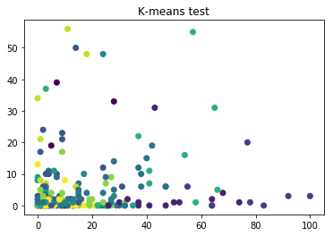

```python
import matplotlib.pyplot as plt

plt.figure()
plt.scatter(data['weekend_visits_p12'], data['kids_spending_score'],c=CustomerGroupKmeans.labels_)
plt.title("K-means test")
plt.show()
```

```python
data['Kmeans_result']=CustomerGroupKmeans.labels_
```

```python
data.to_csv("CustomerGroup_k_means_result.csv")
```

```python
pd.DataFrame(CustomerGroupKmeans.cluster_centers_,columns=['Gender','Age','Annual_Income (k$)','Spending_Score','weekday_visits_p12','weekend_visits_p12','visits_p12','weekday_spending_score','weekend_spending_score','with_kids_visits_p12','with_couple_visits_p12','clothing_spending_score','food&beverage_spending_score','entertainment_spending_score','kids_spending_score']).to_csv("label_centers.csv")
```